# Project2 Phase 2

## Hierarchical clustering

### Start Hour - End Hour

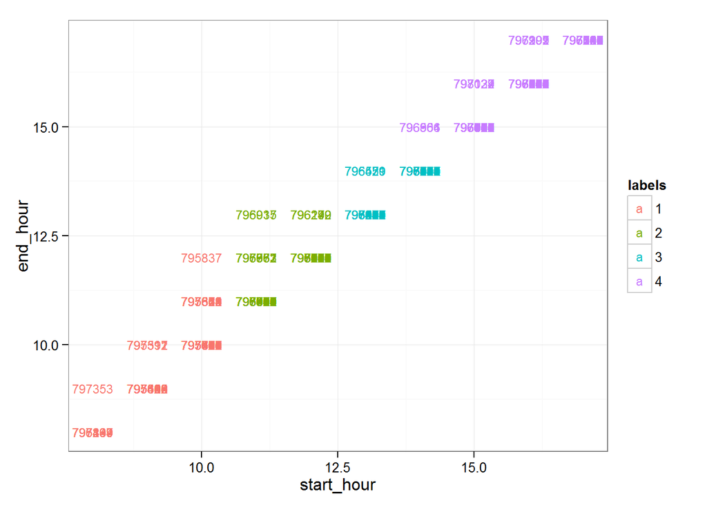

```r
library(ape)
library(RColorBrewer)
cols <- brewer.pal(3,"Set1")

# start hour - end hour
hc <- agnes(start_hour__end_hour, method="ward")
finalData_h$labels = factor(cutree(hc, k=4))
ggplot(finalData_h, aes(start_hour, end_hour, label=Visitor, color=labels)) +
  geom_text(size=3) +
  theme_bw()
```

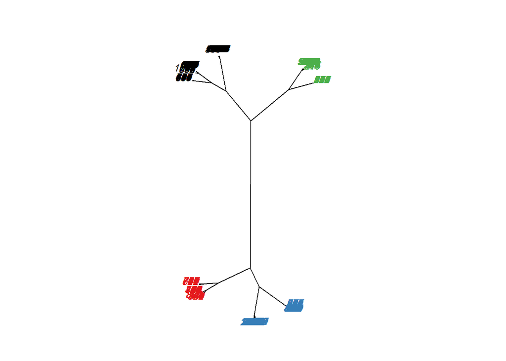

```r
hc <- as.phylo(as.hclust(agnes(start_hour__end_hour, method="ward")))
par(mar=c(1,1,2,1), xpd=NA)
plot(as.phylo(hc), type = "unrooted", cex = 0.8,
     tip.color = cols[finalData_h$labels])
```

```r
rm(start_hour__end_hour)
```

Visitors can be grouped by the hour they started using stations and the hour they ended using stations. It can be seen that we can segment visitors in four different clusters according to those two features. It can be concluded that visitors tend to start and end using stations in the same hour.

### Start Hour - Weekday

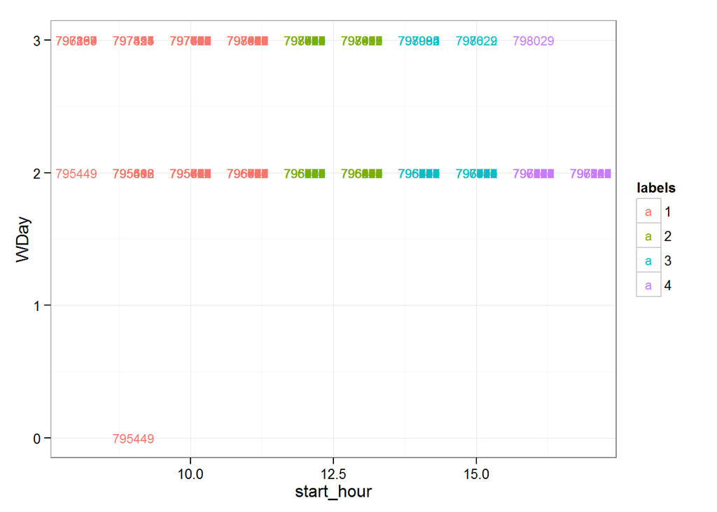

```r
hc <- agnes(start_hour__wday, method="ward")
finalData_h$labels = factor(cutree(hc, k=4))
ggplot(finalData_h, aes(start_hour, WDay, label=Visitor, color=labels)) +
  geom_text(size=3) +
  theme_bw()
```

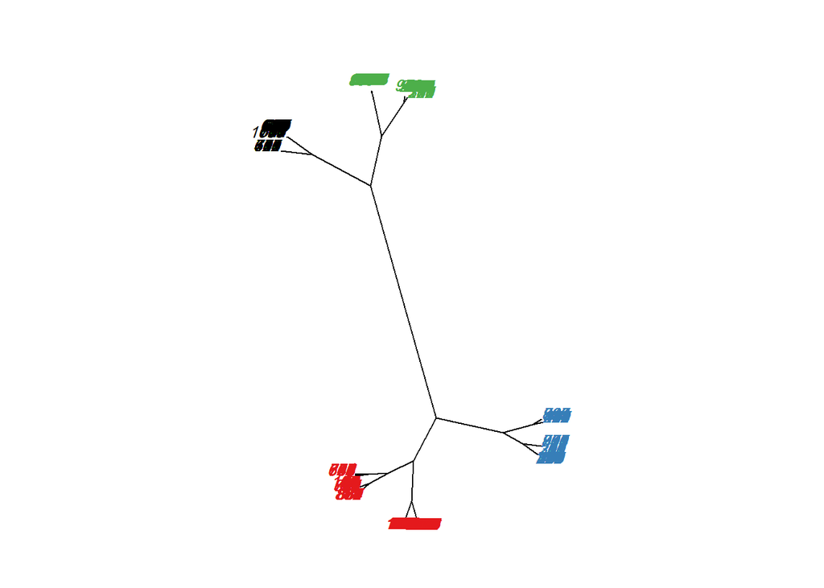

```r
hc <- as.phylo(as.hclust(agnes(start_hour__wday, method="ward")))
par(mar=c(1,1,2,1), xpd=NA)
plot(as.phylo(hc), type = "unrooted", cex = 0.8,
     tip.color = cols[finalData_h$labels])
```

```r
rm(start_hour__wday)
```

### Start Hour - Time of Consuming

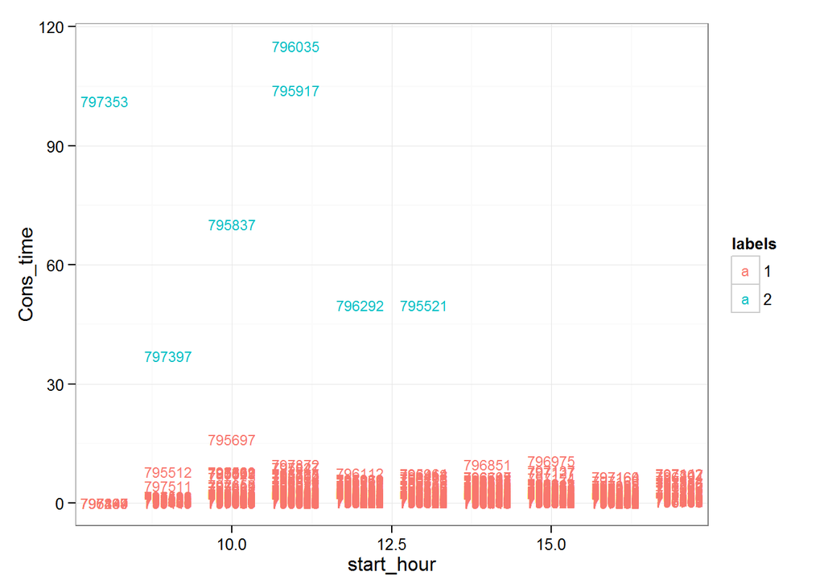

```r
# start hour - the time of consuming
hc <- agnes(start_hour__cons_time, method="ward")
finalData_h$labels = factor(cutree(hc, k=2))
ggplot(finalData_h, aes(start_hour, Cons_time, label=Visitor, color=labels)) +
  geom_text(size=3) +
  theme_bw()
```

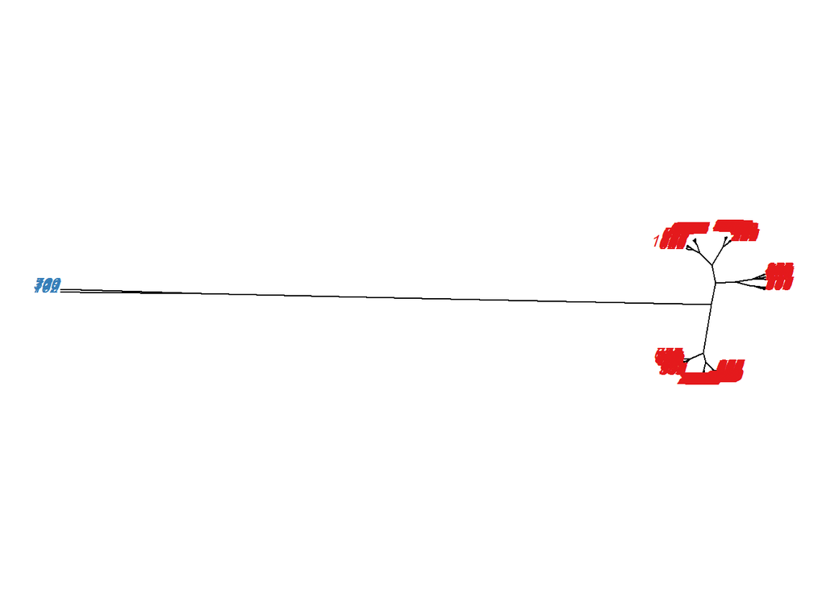

```r
hc <- as.phylo(as.hclust(agnes(start_hour__cons_time, method="ward")))
par(mar=c(1,1,2,1), xpd=NA)
plot(as.phylo(hc), type = "unrooted", cex = 0.8,
     tip.color = cols[finalData_h$labels])
```

```r
rm(start_hour__cons_time)
```

Visitors are grouped by the hour they started using stations and the time of consuming they started using stations. It can be seen that we can segment visitors in two different clusters according to those two features. First cluster is much more bigger than the second one. There are less visitors who tend to consume stations very long at given hour.

### Start Hour - Station

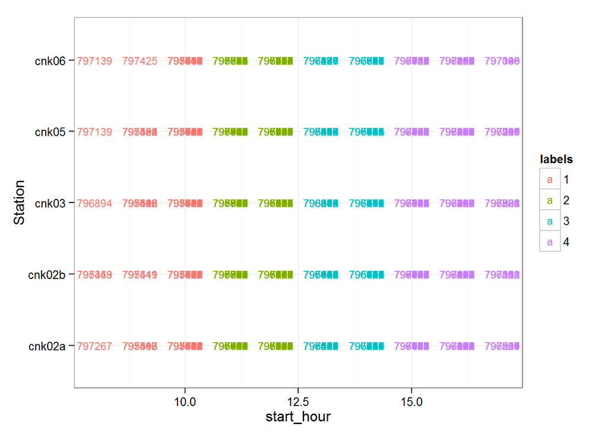

```r
hc <- agnes(start_hour__station, method="ward")
finalData_h$labels = factor(cutree(hc, k=4))
ggplot(finalData_h, aes(start_hour, Station, label=Visitor, color=labels)) +
  geom_text(size=3) +
  theme_bw()
```

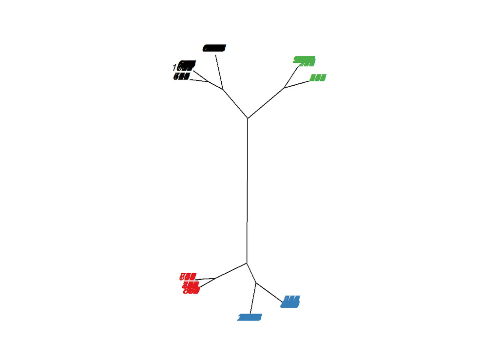

```r
hc <- as.phylo(as.hclust(agnes(start_hour__station, method="ward")))
par(mar=c(1,1,2,1), xpd=NA)
plot(as.phylo(hc), type = "unrooted", cex = 0.8,
     tip.color = cols[finalData_h$labels])
```

```r
rm(start_hour__station)
```

### Weekday - Time of Consuming

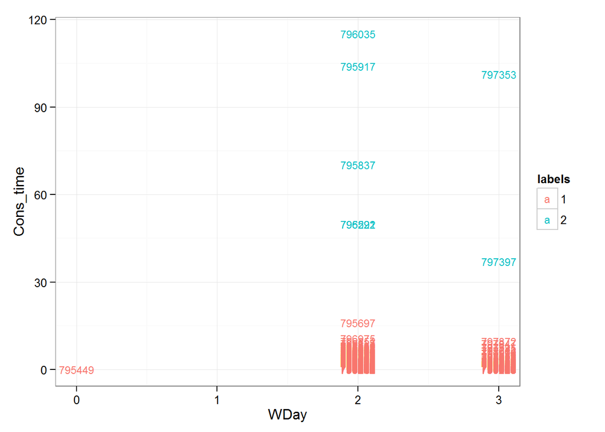

```r
hc <- agnes(wday__cons_time, method="ward")
finalData_h$labels = factor(cutree(hc, k=2))
ggplot(finalData_h, aes(WDay, Cons_time, label=Visitor, color=labels)) +
  geom_text(size=3) +
  theme_bw()
```

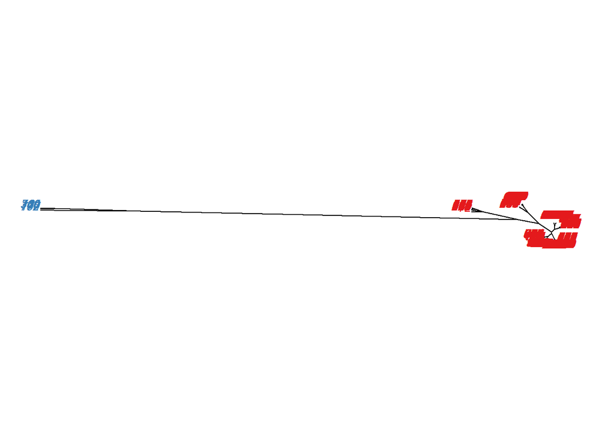

```r
hc <- as.phylo(as.hclust(agnes(wday__cons_time, method="ward")))
par(mar=c(1,1,2,1), xpd=NA)
plot(as.phylo(hc), type = "unrooted", cex = 0.8,
     tip.color = cols[finalData_h$labels])
```

```r
rm(wday__cons_time)
```

Visitors are grouped by the weekday they started using stations and the time of consuming. It can be seen that we can segment visitors in two different clusters according to those two features. Consuming time is very similar for each weekday and those visitors are in the first, larger cluster and in second, smaller cluster are outliers.

### Weekday - Station

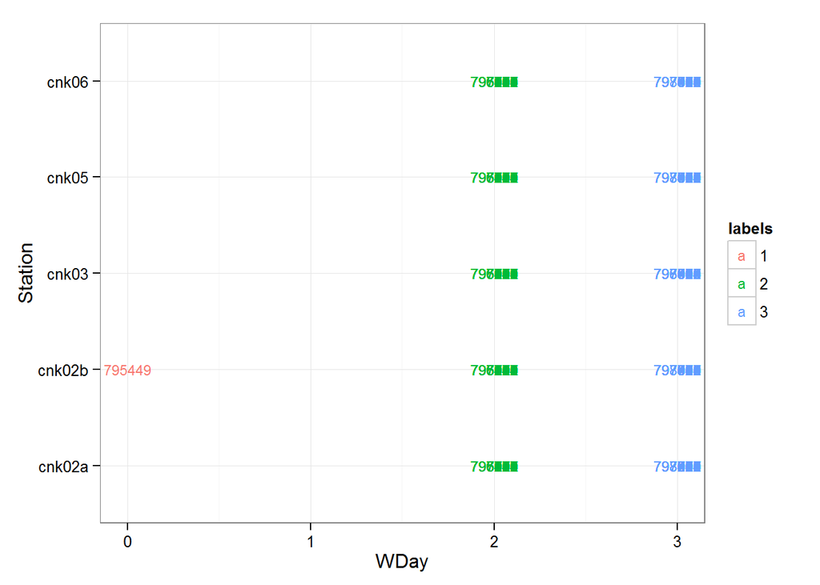

```r
# weekday - station
hc <- agnes(wday__station, method="ward")
finalData_h$labels = factor(cutree(hc, k=3))
ggplot(finalData_h, aes(WDay, Station, label=Visitor, color=labels)) +
  geom_text(size=3) +
  theme_bw()
```

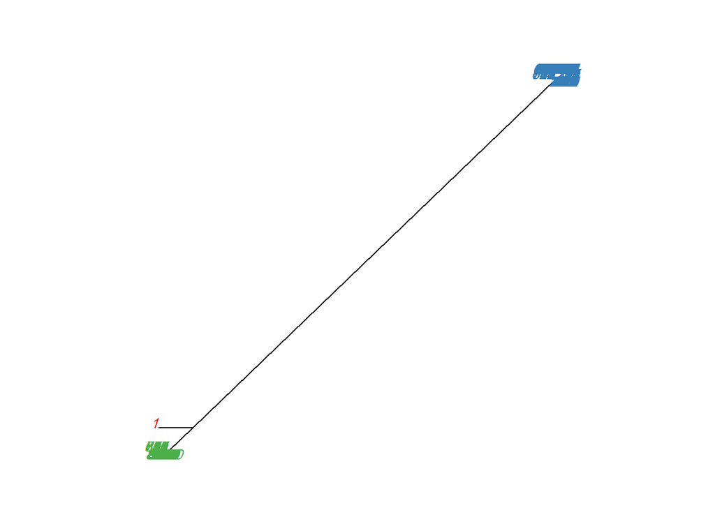

```r
hc <- as.phylo(as.hclust(agnes(wday__station, method="ward")))
par(mar=c(1,1,2,1), xpd=NA)
plot(as.phylo(hc), type = "unrooted", cex = 0.8,
     tip.color = cols[finalData_h$labels])
```

```r
rm(wday__station)
```

Visitors are grouped by the weekday they started using stations and the station. It can be seen that we can segment visitors in three different clusters according to those two features. Each of the stations have almost equal number of visitors each weekday.

### Time of Consuming - Station

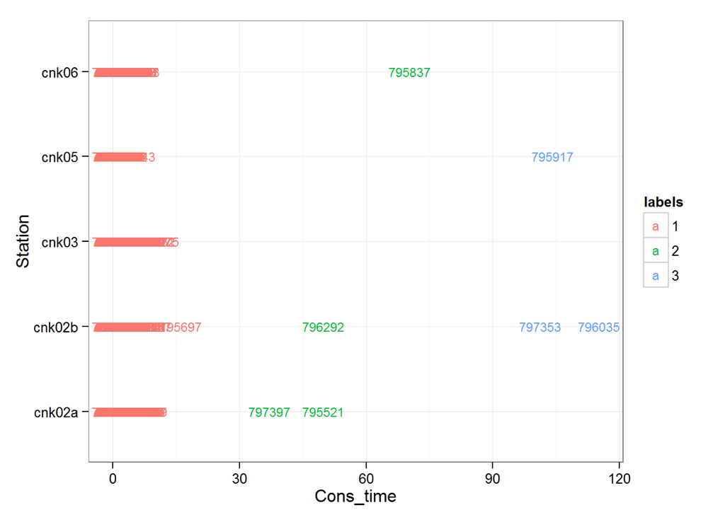

```r
# time of consuming - station
hc <- agnes(cons_time__station, method="ward")
finalData_h$labels = factor(cutree(hc, k=3))
ggplot(finalData_h, aes(Cons_time, Station, label=Visitor, color=labels)) +
  geom_text(size=3) +
  theme_bw()
```

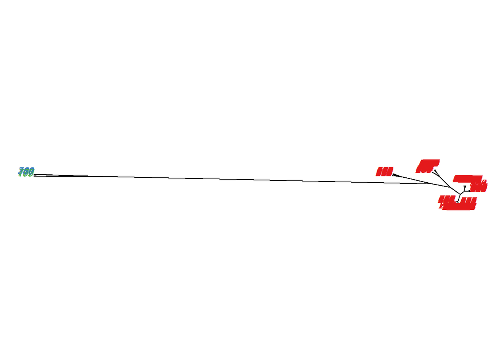

```r
hc <- as.phylo(as.hclust(agnes(cons_time__station, method="ward")))
par(mar=c(1,1,2,1), xpd=NA)
plot(as.phylo(hc), type = "unrooted", cex = 0.8,
     tip.color = cols[finalData_h$labels])
```

```r
rm(cons_time__station)
```

### All Features

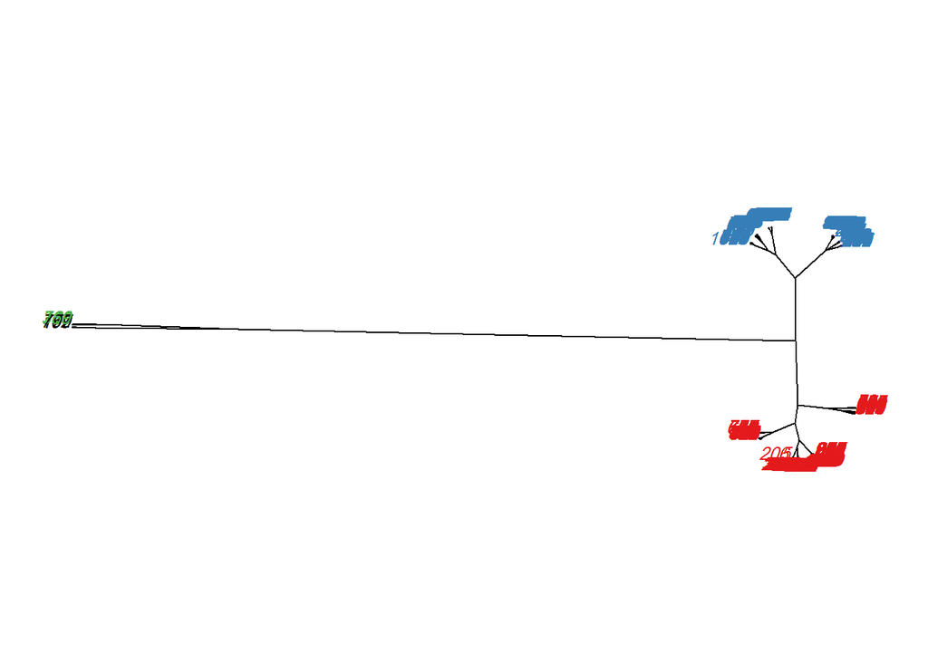

```r
# all features
hc <- agnes(all, method="ward")
finalData_h$labels = factor(cutree(hc, k=4))
hc <- as.phylo(as.hclust(agnes(all, method="ward")))
par(mar=c(1,1,2,1), xpd=NA)
plot(as.phylo(hc), type = "unrooted", cex = 0.8,
     tip.color = cols[finalData_h$labels])
```

```r
rm(all)
```

Visitors are grouped using all features. It can be seen that if we consider all features, we can group visitors in four different groups, there are four main types of visitors, but also it is possible to divide them even into smaller clusters, as it can be seen from the graph.

# Conclusion

How to define the similarity measure between visitors? As above, we calculated similarity between visitors using different models:

- start_hour, end_hour, weekday, consumed_time and station features with Hierarchical clustering.
- Start Time and Consumed Time with k-means and pam
- visited pages with k-means

Is the population homogenous or heterogonous. If heterogeneous then how many groups you can derive/define? Population is heterogeneous as it can be seen from the last graph where we used all features. Four main clusters can be derived, but also we can divide those four classter into smaller ones.

How to characterize different groups of visitors? In different groups of visitors, visitors started using stations on different weekdays, time of consumption is different, hours when they started using station are different, machines they are using are different and so on.

And For K-means and Pam We noticed that:

One Cluster depends on the consumed time, and this cluster contains the visits which have consumed time bigger than three minutes. while both of the second and the third clusters contain the records which have consumed time less than three (approximatly), but the visits in one of them started before jan 16, and the other after 16 Jan.

And the visted pages table describe the clusters when we used the interactions dataset.